# Exploratory Assessment of the Downscaled GRACE product

Tejasvi Hora

2022-10-16

## Introduction

This report relies on the downscaled GRACE data-provided by **Prof. Di Long, Li Chen and Ximing Wang.**

The purpose of this report is to:

- Exploratory Assessment of the downscaled GRACE-GWS (groundwater storage anomaly)
- Comparison of the downscaled product with in-situ well measurements in India
- Comparison of the downscaled 0.5 degree product and non-Downscaled interpolated GRACE dataset (the one I had produced)

**Please note:** It appears that the downscaled product now covers entire regions (i.e. SA, MENA and SSA). It will be worth discussing the methodology used to move from individual basins to regions.

## Load and pre-process the datasets

Main steps involved:

- Loading the dataset: `GWS_mean_05deg.nc`
- Linking points with World Bank regions data

## Trend Analysis

The steps involved in assessing trends were:

- Conversion of monthly GWS estimates to annual
- Estimating *linear* trends by estimating Sen’s Slope
- Significance of trend not assessed

### MENA

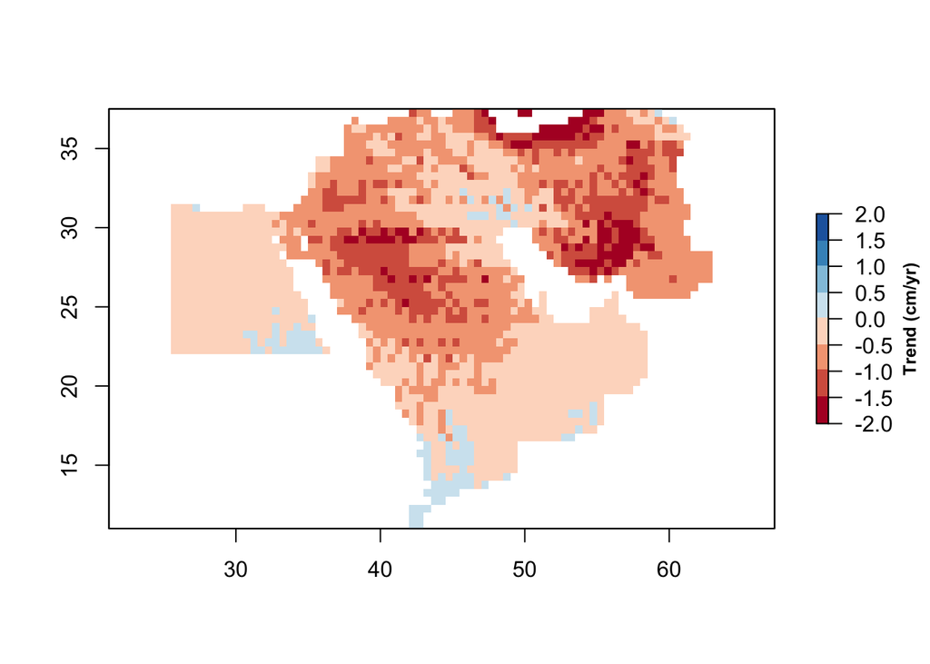

### SSA

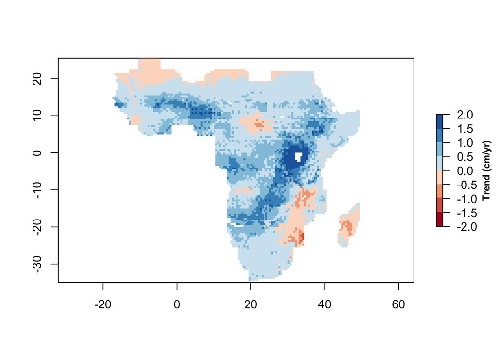

### SA

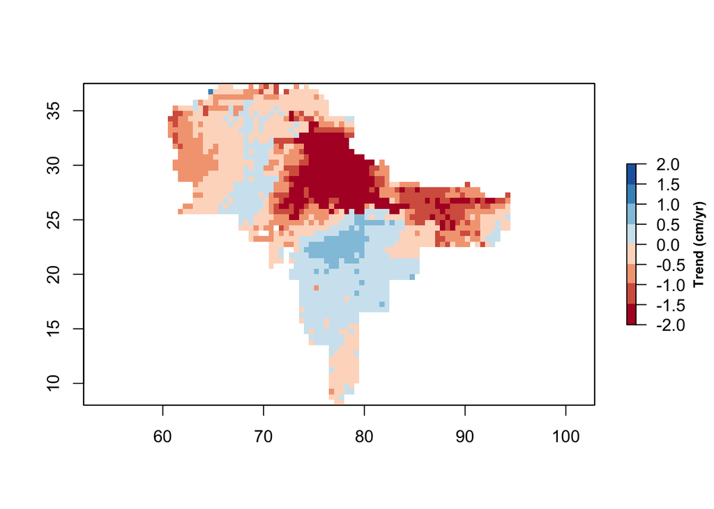

## Comparison with In-situ data

In this section, the downscaled GRACE data was compared with in-situ well data in India.

The main steps involved in the comparison included:

- Linking individual wells to pixels
- Subsetting the available wells to wells with relatively continuous time-series. For dug-wells, wells with <20 missing points were included; for bore wells, wells with <50 missing points were included
- Calculating a mean water-level time-series for each pixels based on the wells in that pixel
- Linking the well-based TS with the downscaled GRACE product for the same months
- Estimating the correlation co-efficient between the two

Information about the wells data:

- 28076 wells (bore well + dug wells)
- Available for 4 months of the year (Jan, May, Aug and Nov)
- 1996-2017

### Dug-wells

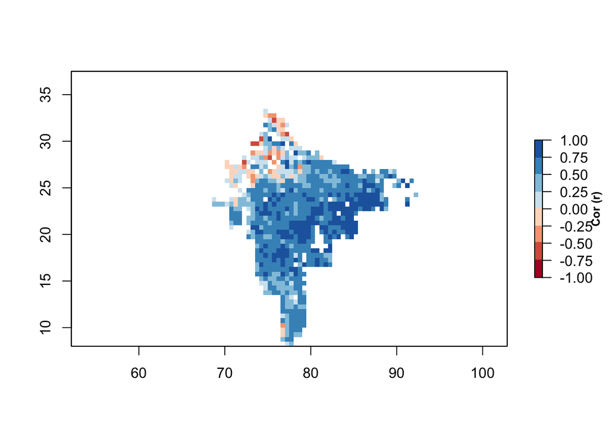

### Bore-wells

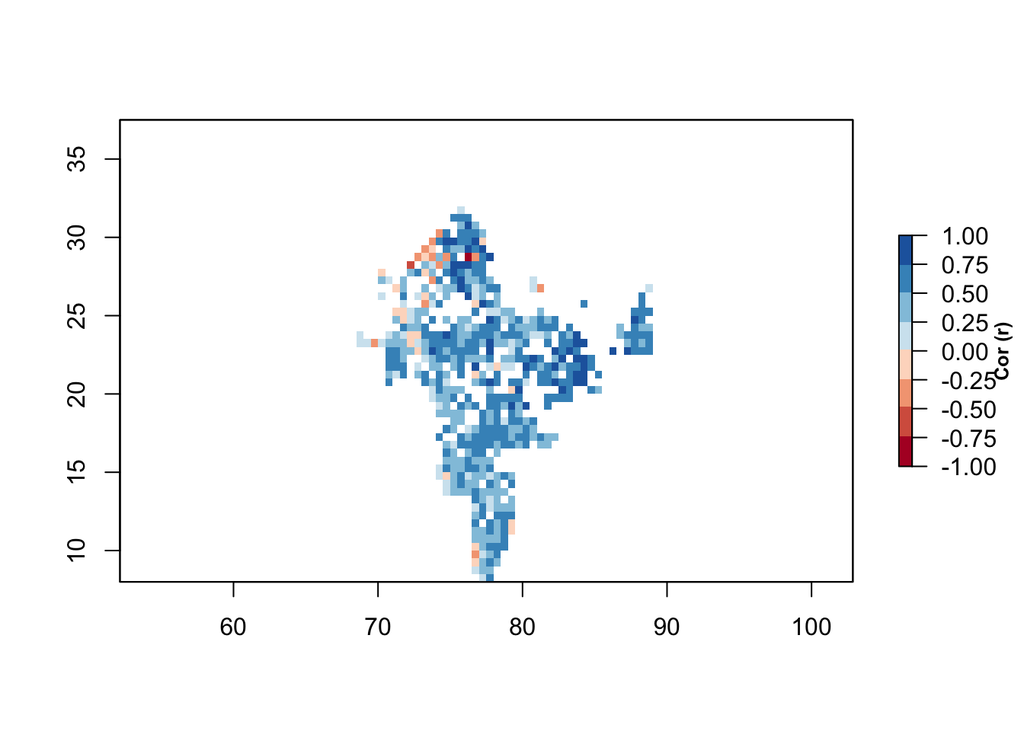

## Comparison with non-downscaled GRACE data

In this section, the downscaled GRACE data was compared with the non-downscaled GRACE products

The main steps involved in the comparison included:

- Disaggregating the 1 degree non-downscaled GRACE grid to 0.5 degrees
- Linking the downscaled and non-downscaled GRACE grids
- Estimating the correlation co-efficient between the downscaled and non-downscaled grids

Information about the non-downscaled GRACE grid:

- 1 degree resolution

### MENA

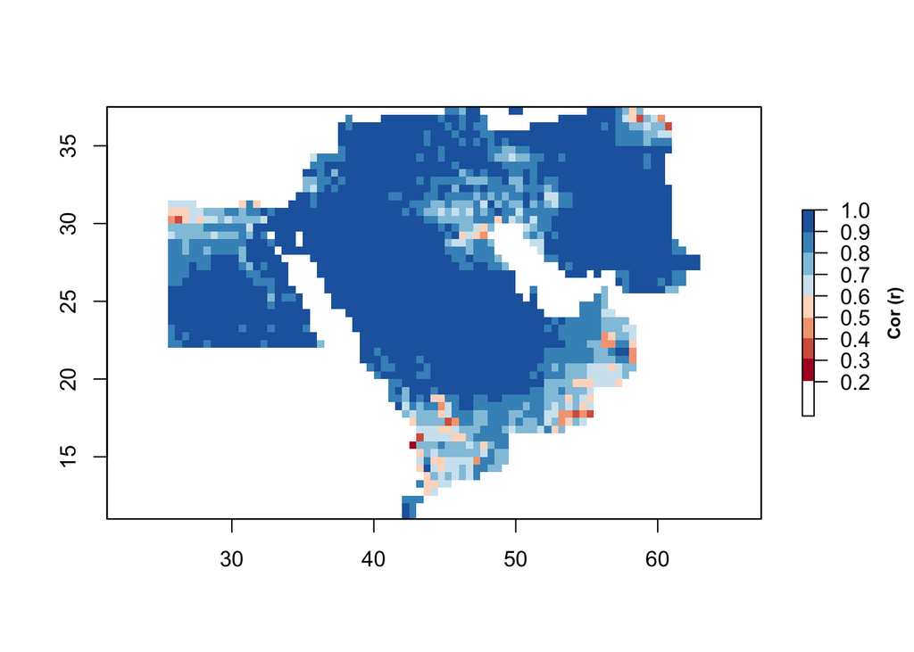

### SSA

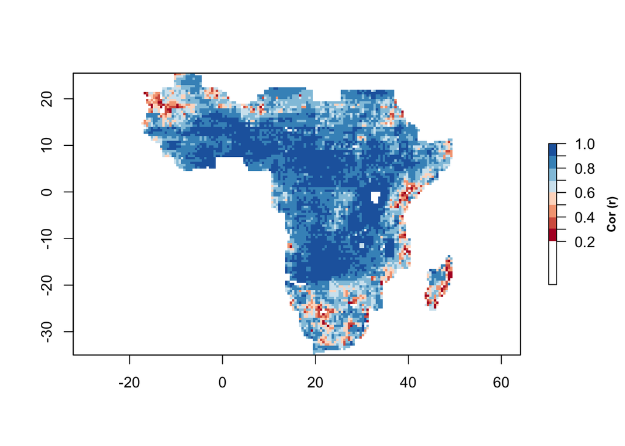

### South Asia

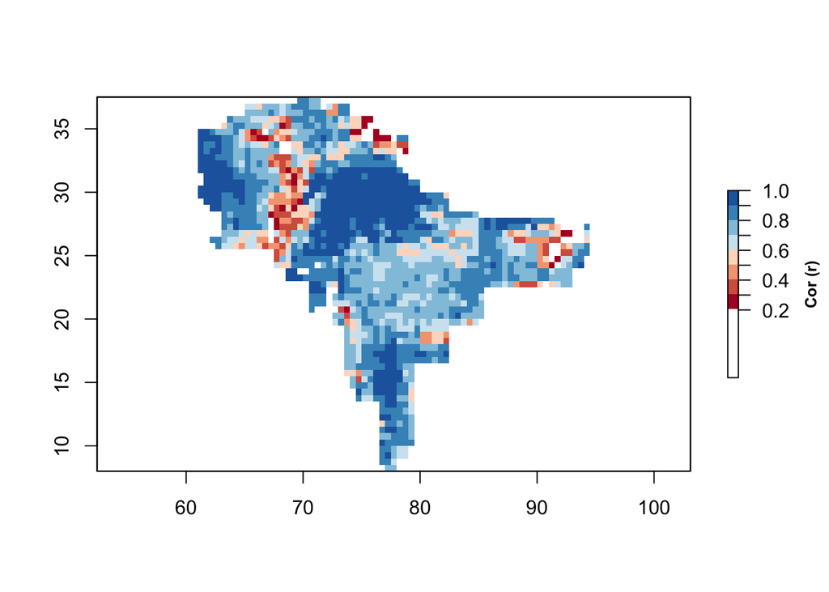

Results show moderate to poor correlation between the two GRACE products in:

- Yemen/Oman region
- Mouth of the Nile Basin
- Region close to Kuwait
- South Africa/Madagascar/Western Sahara
- Bengal/Indus River Basin/Central India